#### 18.04.23, © Dmitro Akhinian, 2023

# Лабораторна робота №8. Модулі, пакети та pip

**Мета:** *навчитися імпортувати, користуватися, створювати модулі та пакети. Навчитися користуватися "сирною крамницею" PyPi та менеджером пакетів `pip`*

## Створення модуля

### Завдання 1

Створити модуль `module.py` та файл `main.py`, структура яких описана у лекції 9, повторишви кроки 1-10.

```python
#!/usr/bin/env python3

__counter = 0


def suml(the_list):
    global __counter
    __counter += 1
    the_sum = 0
    for element in the_list:
        the_sum += element
    return the_sum


def prodl(the_list):
    global __counter
    __counter += 1
    prod = 1
    for element in the_list:
        prod *= element
    return prod


if __name__ == "__main__":
    print("I prefer to be a module, but I can do some tests for you.")
    my_list = [i + 1 for i in range(5)]
    print(suml(my_list) == 15)
    print(prodl(my_list) == 120)
```

```
I prefer to be a module, but I can do some tests for you.
True
True
```

```python
import module

zeroes = [0 for i in range(5)]
ones = [1 for i in range(5)]
print(module.suml(zeroes))
print(module.prodl(ones))
```

[output not shown]

## Створення пакета

### Завдання 2

Створити пакет `extra`, структура яких описана у лекції 9, повторишви кроки 1-7, завантаживши потрібні файли за навкденими нижче посиланнями:

Modules and Packages ZIP file.zip

Extrapack ZIP file.zip

### Для Modules and Packages ZIP file (кроки 1 - 6)

```python
from sys import path
path.append('..\\packages')

# import extra.iota
#
# print(extra.iota.FunI())

import extra.good.best.sigma
from extra.good.best.tau import FunT

print(extra.good.best.sigma.FunS())
print(FunT())
```

[output not shown]

### Для Extrapack ZIP file (крок 7)

```python
from sys import path
path.append('..\\packages\\extrapack.zip')

import extra.good.best.sigma as sig
import extra.good.alpha as alp
from extra.iota import FunI
from extra.good.beta import FunB

print(sig.FunS())
print(alp.FunA())
print(FunI())
print(FunB())
```

[output not shown]

## Робота з менеджером пакетів `pip`

Список основних команд `pip`:

- `pip help operation` – показує короткий опис pip;
- `pip list` – показує список встановлених пакетів;
- `pip show package_name` – показує інформацію про package_name, включаючи залежність пакета;
- `pip search anystring` – виконує пошук у каталогах PyPI, щоб знайти пакети, імена яких містять anystring;
- `pip install name` – встановлює name у масштабі всієї системи (очікуйте проблем, якщо у Вас немає прав адміністратора);
- `pip install` --user name – встановлює name лише для Вас; жоден інший користувач платформи не зможе його використовувати;
- `pip install -U name` – оновлює раніше встановлений пакет;
- `pip uninstall name` – видаляє встановлений раніше пакет.

### Завдання 3

За допомогою менеджера пакетів `pip`:

- вивести перелік встановлених на Вашому комп'ютері пакетів
- знайти і встановити пакет `pygame`
- вивести інформацію про `pygame`
- запустити код, наведений нижче
- деінсталювати пакет `pygame`

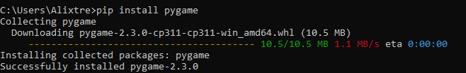

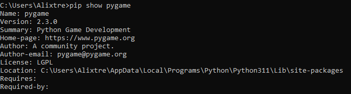

[figure not shown]

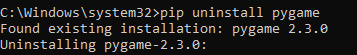

```python
# import pygame

# run = True
# width = 400
# height = 100
# pygame.init()
# screen = pygame.display.set_mode((width, height))
# font = pygame.font.SysFont(None, 48)
# text = font.render("Welcome to pygame", True, (255, 255, 255))
# screen.blit(text, ((width - text.get_width()) // 2, (height - text.get_height()) // 2))
# pygame.display.flip()
# while run:
#     for event in pygame.event.get():
#         if event.type == pygame.QUIT\
#         or event.type == pygame.MOUSEBUTTONUP\
#         or event.type == pygame.KEYUP:
#             run = False
```

### Контрольні запитання

1. Ви хочете заборонити користувачеві модуля запускати ваш код як звичайний скрипт. Як досягти такого ефекту? Написати код.
1. Деякі додаткові та необхідні пакети зберігаються в каталозі D:\Python\Project\Modules. Напишіть код, який забезпечує перегляд каталогу Python для пошуку всіх модулів. Написати код.
1. Каталог, згаданий у попередній вправі, містить піддерево наступної структури:

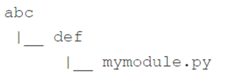

Припускаючи, що `D:\Python\Project\Modules` був успішно доданий до списку `sys.path`, напишіть директиву імпорту, що дозволяє використовувати всі сутності з `mymodule`.

### Відповіді на контрольні запитання

2. import sys  
   sys.path.append("D:\Python\Project\Modules")
3. import abc.def.mymodule